# Stat 324 HW6: Hypothesis Tests for 2 Independent Populations

Devin Johnson, Dis. 313

November 3, 2018

## Problem 1

```r
# Data for problem 1
n_am = 8
n_eu = 5
xbar_am = 220
xbar_eu = 204
svar_am = 21
svar_eu = 23
alpha = 0.1
```

**–1A: Plots and statistics–**  
A two sample t test with equal variance assumption is appropriate for the following reasons:

- We have two independent populations which we would like to compare.
- We can assume both populations are normally distributed.
- Samples are independent and random.
- We find $\frac{sd_{am}}{sd_{eu}} = \frac{\sqrt{21}}{\sqrt{23}} = 0.96$ and $0.5<0.96<2$ so we can assume equal variances.

$H_o: \mu_{am} - \mu_{eu} = 0$  
$H_a: \mu_{am} - \mu_{eu} > 0$  
$\alpha = 0.1$

**–1B: t test w/ equal variances–**

```r
sp = sqrt(((n_am - 1)*(svar_am) + (n_eu -1)*(svar_eu)) / (n_am + n_eu - 2)) # Pooled SD
t_obs = (xbar_am - xbar_eu) / (sp*sqrt((1/n_am) + (1/n_eu))) # t statistic
crit_t = abs(qt(alpha/2, n_am + n_eu - 2)) # t n1+n2-2,alpha/2

diff_obs = (t_obs) * (sp*sqrt((1/n_am) + (1/n_eu))) # Get the raw value of xbars
crit_diff = (crit_t) * (sp*sqrt((1/n_am) + (1/n_eu)))

cat(paste(" Pooled SD:", sp, "\n", "t observed:", t_obs, "\n", "Critical t:", crit_t, "\n", "Observed xbar difference:", diff_obs, "\n", "Critical xbar difference:", crit_diff))
```

```
##  Pooled SD: 4.66125227028883
##  t observed: 6.02109797762263
##  Critical t: 1.79588481870404
##  Observed xbar difference: 16
##  Critical xbar difference: 4.7722453954503
```

Our t statistic falls into the rejection region and our observed difference in xbars is greater than our critical difference. Therefore, we reject $H_o$

**–1C: P value of 1B test–**

```r
pval = pt(q = t_obs, df = n_am + n_eu - 2, lower.tail = FALSE) # Calculate pvalue (one-sided, above)
print(pval)
```

```
## [1] 0.00004329998
```

Our p value is significantly $< \alpha$, so we reject $H_o$.

**–1D: Changing $\delta_o$–** This would change our $\delta_o$ which would affect the numerator of our t observed value. The numerator would become smaller and thus the area above the t observed value would be greater. This area corresponds to the p-value. Thus the p-value would be greater for this test.

**–1E: t test w/ unequal variances–** We make the assumption that the variances are not equal.

```r
tobs_welch = (xbar_am - xbar_eu - 0) / (sqrt((svar_am/n_am) + (svar_eu/n_eu)))
df_welch = (((svar_am/n_am)+(svar_eu/n_eu))^2) / (((svar_am/n_am)^2 / (n_am - 1)) + ((svar_eu/n_eu)^2 / (n_eu - 1)))
pval_welch = 1- pt(q = tobs_welch, df = df_welch)

cat(paste(" T observed:", tobs_welch, "\n", "P Value:", pval_welch))
```

```
##  T observed: 5.9525226544346
##  P Value: 0.000146345695011707
```

This P value is larger though it is still able to reject $H_o$

## Problem 2

```r
# Data for problem 2
midwest = c(16.2,12.9,17.3,14.6,18.6,10.8,11.2,16.6,16.6,24.4,20.3,20.9,9.6,15.1,18.3)
south = c(22.2,19.2,9.3,24.6,20.2,15.8,18.0,12.2,20.1,16.0,17.5,18.2,22.8,11.5)
alpha = 0.1
```

**–2A: Plots and statistics–**  
I chose histograms to get a view of the variances of samples side by side and I chose QQ plots to assess the normality of the two populations.

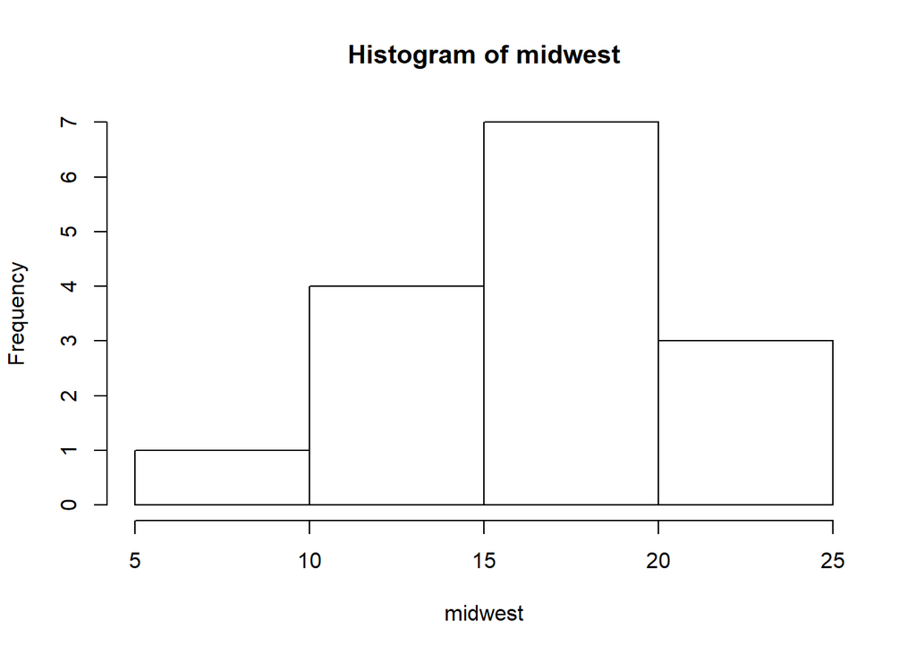

```r
# Plots
hist(midwest)
```

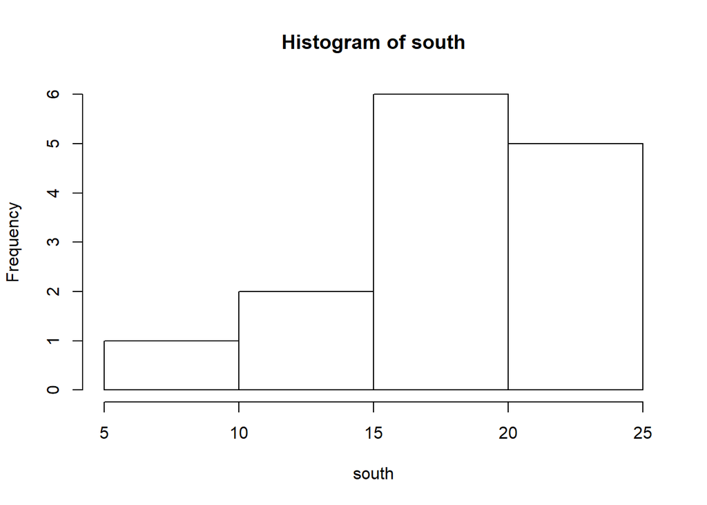

```r
hist(south)
```

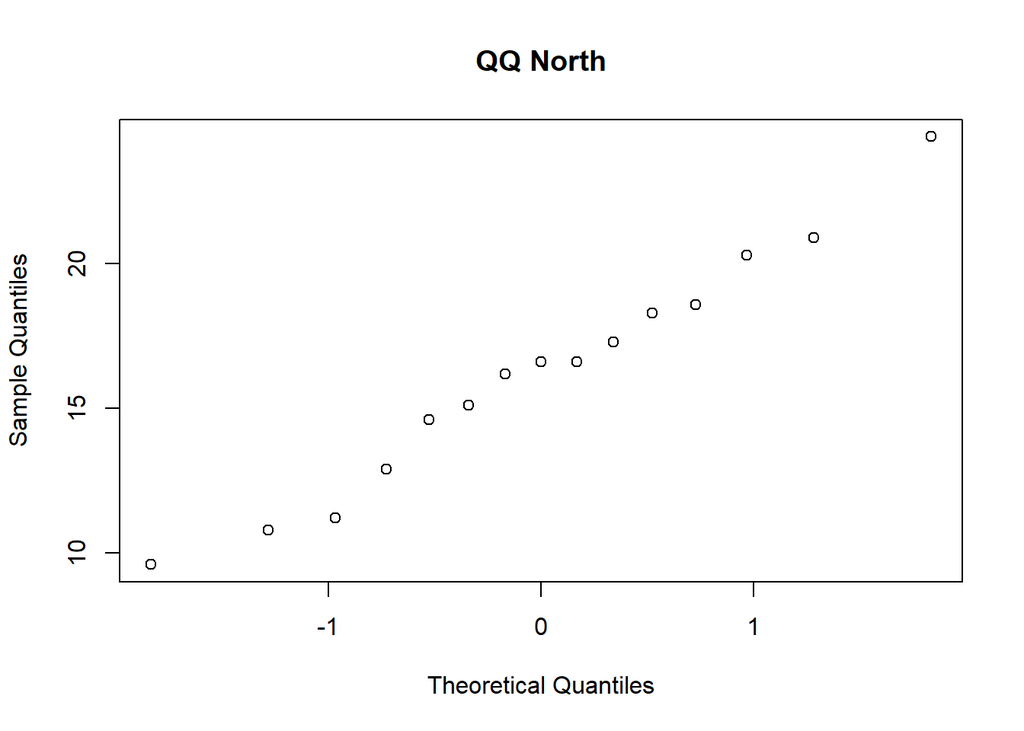

```r
qqnorm(midwest, main = "QQ North")
```

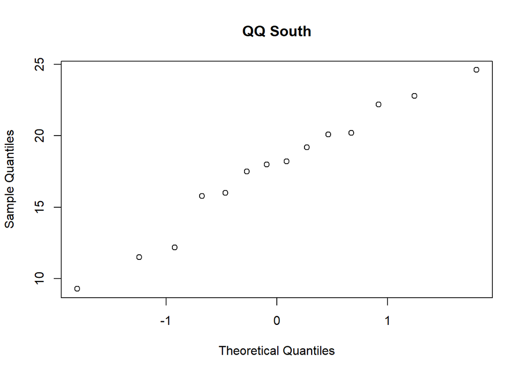

```r
qqnorm(south, main = "QQ South")
```

```r
# Sample statistics
xbar_midwest = mean(midwest)
xbar_south = mean(south)
svar_midwest = var(midwest)
svar_south = var(south)
n_midwest = length(midwest)
n_south = length(south)
```

**–2B: t test with equal variances–**  
Assumptions:

- Assuming two independent populations.
- Assuming both populations are normally distributed (by QQ plot)
- Assuming samples are independent and random.
- We find $\frac{sd_{m}}{sd_{s}} = \frac{\sqrt{16.44}}{\sqrt{19.56}} = 0.92$ and $0.5<0.92<2$ so we can assume equal variances.

$H_o: \mu_{m} - \mu_{s} = 0$  
$H_a: \mu_{m} - \mu_{s} \neq 0$  
$\alpha = 0.1$

```r
sp = sqrt(((n_midwest - 1)*(svar_midwest) + (n_south -1)*(svar_south)) / (n_midwest + n_south - 2)) # Pooled SD
tobs = (xbar_midwest - xbar_south - 0) / (sp*sqrt((1/n_midwest) + (1/n_south))) # t statistic
crit_t = abs(qt(alpha/2, n_midwest + n_south - 2)) # t n1+n2-2,alpha/2
pval = 2*pt(q = tobs, df = n_midwest + n_south - 2) # Calculate pvalue (two-sided)

cat(paste(" Pooled SD:", sp, "\n", "t observed:", tobs, "\n", "Critical t:", crit_t), "\n", "P value:", pval, "\n")
```

```
##  Pooled SD: 4.23594178688394
##  t observed: -0.926894129444781
##  Critical t: 1.70328844572213
##  P value: 0.3621934
```

P value from calculator: 0.3621934  
P value from table: P > 0.25  
Our p value is significantly $> \alpha$, so we fail to reject $H_o$.

**–2C: 90% confidence interval w/ equal variances–**

```r
# Calculate confidence interval manually (uses data from part b)
l = (xbar_midwest - xbar_south) - (crit_t * sp * sqrt((1/n_midwest) + (1/n_south)))
u = (xbar_midwest - xbar_south) + (crit_t * sp * sqrt((1/n_midwest) + (1/n_south)))
cat(paste(" l:", l, "\n", "u", u))
```

```
##  l: -4.14023727419285
##  u 1.22214203609761
```

```r
# Calculate using R functions
t.test(midwest, south, var.equal = TRUE, mu = 0, alternative = "two.sided", conf.level = 0.9)
```

```
##
##  Two Sample t-test
##
## data:  midwest and south
## t = -0.92689, df = 27, p-value = 0.3622
## alternative hypothesis: true difference in means is not equal to 0
## 90 percent confidence interval:
##  -4.140237  1.222142
## sample estimates:
## mean of x mean of y
##  16.22667  17.68571
```

The confidence interval tells us that of 90% of the time we create a confidence interval in such a manner, we would capture the true difference in means. This differs from a simple hypothesis test because the hypothesis test only gives us evidence as to whether the true difference in means in greater, less, or equal to $H_o$. The confidence interval instead gives us a range of possible true differences.

## Problem 3

```r
# Data for problem 3
dynamic = c(370,360,510,445,295,315,490,345,450,505,335,280,325,500)
static = c(430,445,455,455,490,535)
alpha = 0.05
```

**–3A: Plots and statistics–** I chose histograms to get a view of the variances of samples side by side and I chose QQ plots to assess the normality of the two populations.

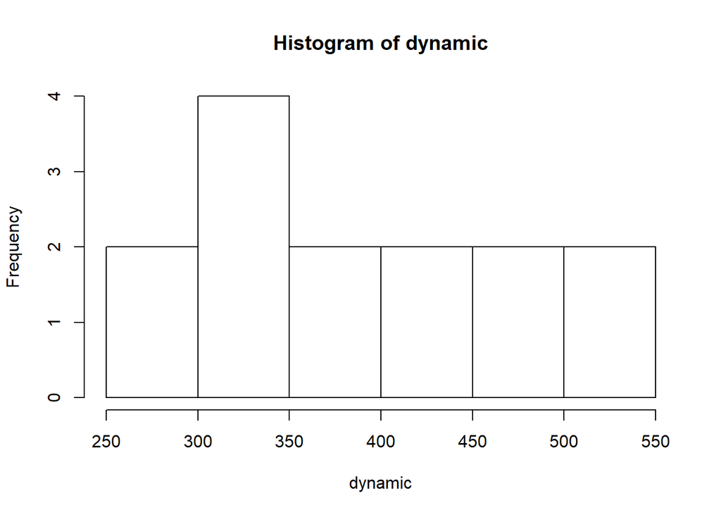

```r
# Plots
hist(dynamic)
```

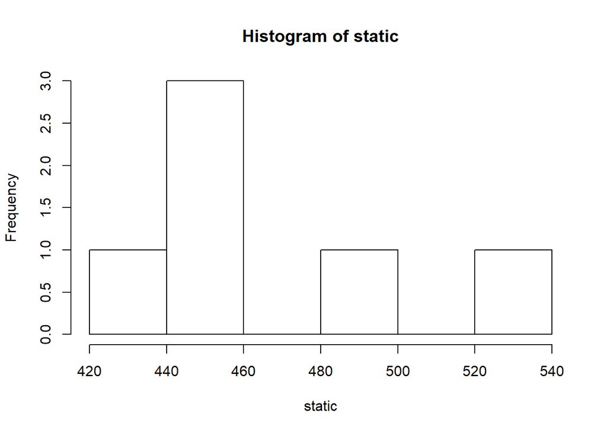

```r
hist(static)
```

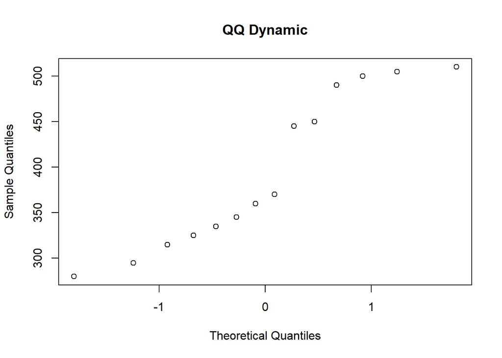

```r
qqnorm(dynamic, main = "QQ Dynamic")
```

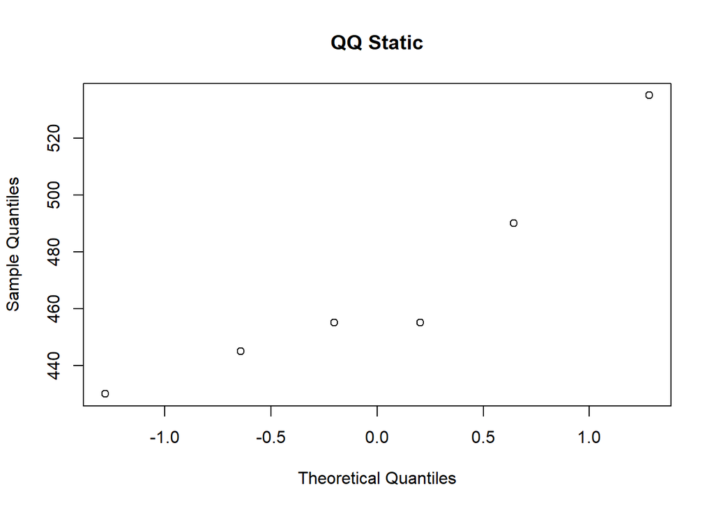

```r
qqnorm(static, main = "QQ Static")
```

```r
# Sample statistics
xbar_dynamic = mean(dynamic)
xbar_static = mean(static)
svar_dynamic = var(dynamic)
svar_static = var(static)
n_dynamic = length(dynamic)
n_static = length(static)
```

**–3B: t test w/ unequal variancecs–** Assumptions:

- Assuming two independent populations.
- Assuming both populations are normally distributed (even though QQ plot doesn’t look too good.)
- Assuming samples are independent and random.
- We assume unequal variances.

$H_o: \mu_{dynamic} - \mu_{static} = 0$  
$H_a: \mu_{dynamic} - \mu_{static} < 0$  
$\alpha = 0.05$

```r
# Use welch t test since unequal variances
tobs_welch = (xbar_dynamic - xbar_static - 0) / (sqrt((svar_dynamic/n_dynamic) + (svar_static/n_static)))
df_welch = (((svar_dynamic/n_dynamic)+(svar_static/n_static))^2) / (((svar_dynamic/n_dynamic)^2 / (n_dynamic - 1)) + ((svar_static/n_static)^2 / (n_static - 1)))
pval_welch = pt(q = tobs_welch, df = df_welch) # By default pt gets area under t value

cat(paste(" T observed:", tobs_welch, "\n", "P Value:", pval_welch))
```

```
##  T observed: -2.68042040423957
##  P Value: 0.00767906481932645
```

Our p value is $<\alpha$ so we reject $H_o$

**–3C: 95% CI w/ unequal variances–**

```r
# Statistics required for CI
alpha = 0.05
crit_t = abs(qt(alpha/2, df_welch)) # t n1+n2-2,alpha/2
multiplier = sqrt((svar_dynamic/n_dynamic) + (svar_static/n_static))

# Calculate confidence interval manually assuming no pooling (uses data from part b) (USING TWO SIDED AS PER https://piazza.com/class/jlld5abk9jz46m?cid=202)
l = (xbar_dynamic - xbar_static) - (crit_t * sqrt((svar_dynamic/n_dynamic) + (svar_static/n_static)))
u = (xbar_dynamic - xbar_static) + (crit_t * sqrt((svar_dynamic/n_dynamic) + (svar_static/n_static)))
cat(paste(" l:", l, "\n", "u", u))
```

```
##  l: -131.488263058754
##  u -15.8926893221982
```

```r
# Calculate using R functions (USING TWO SIDED AS PER https://piazza.com/class/jlld5abk9jz46m?cid=202)
t.test(dynamic, static, var.equal = FALSE, mu = 0, alternative = "two.sided", conf.level = 0.95)
```

```
##
##  Welch Two Sample t-test
##
## data:  dynamic and static
## t = -2.6804, df = 17.832, p-value = 0.01536
## alternative hypothesis: true difference in means is not equal to 0
## 95 percent confidence interval:
##  -131.48826  -15.89269
## sample estimates:
## mean of x mean of y
##  394.6429  468.3333
```

The confidence interval tells us that of 95% of the time we create a confidence interval in such a manner, we would capture the true difference in means. This differs from a simple hypothesis test because the hypothesis test only gives us evidence as to whether the true difference in means in greater, less, or equal to $H_o$. The confidence interval instead gives us a range of possible true differences.

## Problem 4

```r
# Data for problem 4
a = c(23.1,21.4,31.6,34.5,21.9,36.0,30.2,33.1,39.5)
b = c(32.7,36.8,39.1,37.3,40.3,46.8,41.4,53.0,55.6,54.1,28.3)
alpha = 0.05
```

**–4A: Plots and statistics–** I chose histograms to get a view of the variances of samples side by side and I chose QQ plots to assess the normality of the two populations.

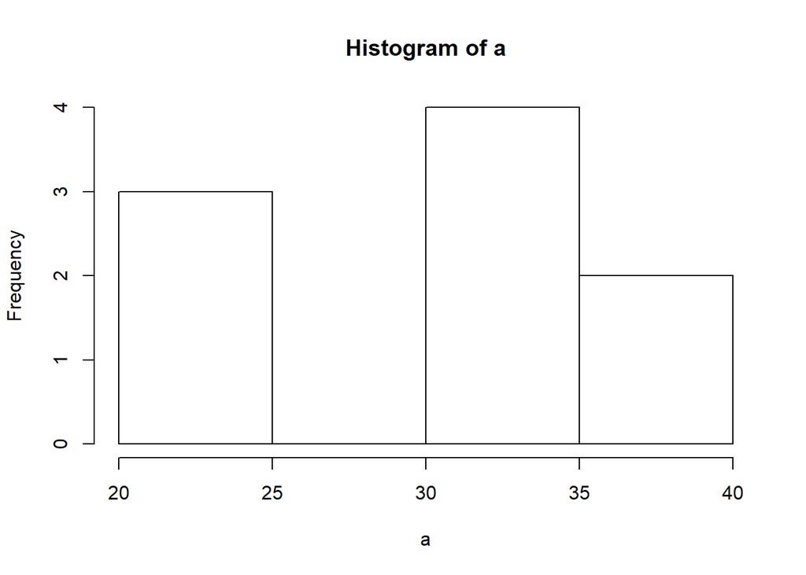

```r
# Plots
hist(a)
```

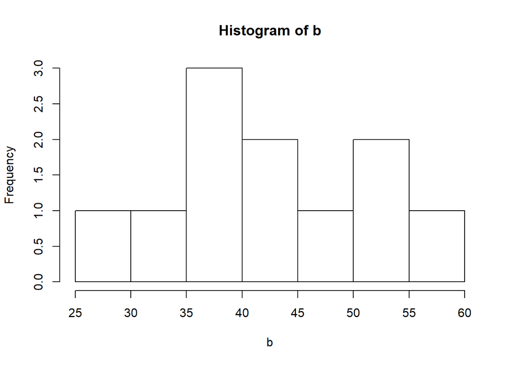

```r
hist(b)
```

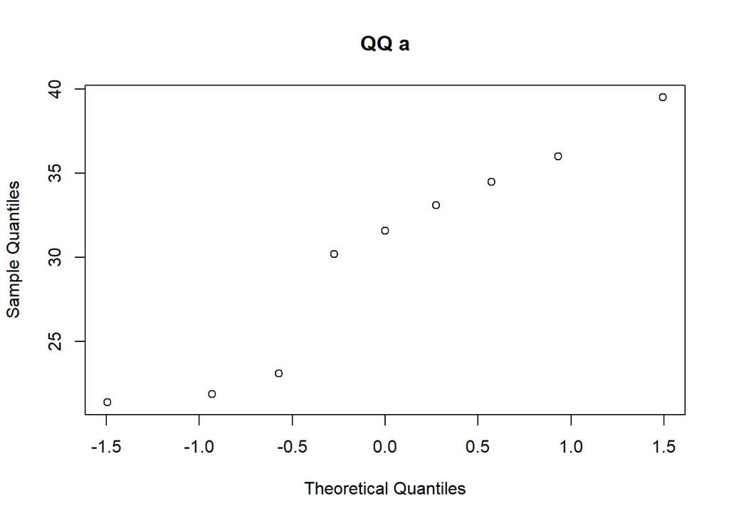

```r
qqnorm(a, main = "QQ a")
```

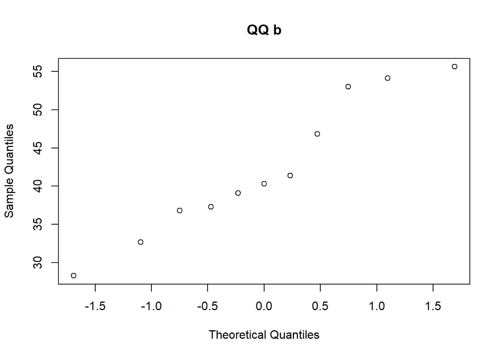

```r
qqnorm(b, main = "QQ b")
```

```r
# Sample statistics
xbar_a = mean(a)
xbar_b = mean(b)
svar_a = var(a)
svar_b = var(b)
n_a = length(a)
n_b = length(b)
```

**–4B: Bootstrap Test–**

```r
# Bootstrap function
boottwo = function(dat1, dat2, nboot) {
  bootstat = numeric(nboot)
  obsdiff = mean(dat1) - mean(dat2)
  n1 = length(dat1)
  n2 = length(dat2)
  for(i in 1:nboot) {
    samp1 = sample(dat1, size = n1, replace = T)
    samp2 = sample(dat2, size = n2, replace = T)
    bootmean1 = mean(samp1)
    bootmean2 = mean(samp2)
    bootvar1 = var(samp1)
    bootvar2 = var(samp2)
    bootstat[i] = ((bootmean1 - bootmean2) - obsdiff)/sqrt((bootvar1/n1) + (bootvar2/n2))
}
  return(bootstat)
}
```

$H_o: \mu_{a} - \mu_{b} = 0$  
$H_a: \mu_{a} - \mu_{b} \neq 0$  
$\alpha = 0.05$

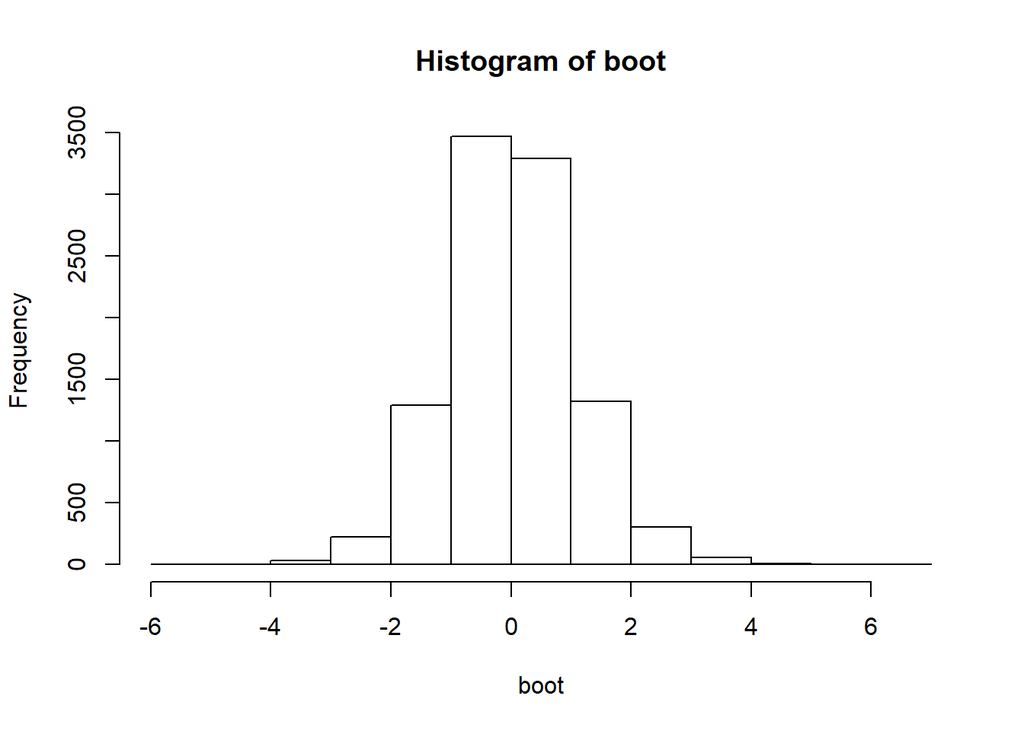

```r
# Create distribution
set.seed(1)
boot = boottwo(a, b, 10000)
hist(boot)
```

```r
# Perform test
t_obs = (xbar_a - xbar_b) / sqrt((svar_a / n_a)  + (svar_b / n_b))
m_equal = sum(boot == t_obs)
m_low  = sum(boot < t_obs)
m_high = sum(boot > t_obs)
pval = m_low/ 10000

cat(paste(" T observed:", t_obs, "\n", "P Value:", pval))
```

```
##  T observed: -3.48860124525757
##  P Value: 0.0013
```

Conclusion: P value is significantly $<\alpha$ so reject $H_o$.

**–4C: t tests–**

```r
# Using R functions
t.test(a, b, var.equal=TRUE, alternative="two.sided")
```

```
##
##  Two Sample t-test
##
## data:  a and b
## t = -3.3786, df = 18, p-value = 0.003346
## alternative hypothesis: true difference in means is not equal to 0
## 95 percent confidence interval:
##  -19.72893  -4.60036
## sample estimates:
## mean of x mean of y
##  30.14444  42.30909
```

```r
t.test(a, b, var.equal=FALSE, alternative="two.sided")
```

```
##
##  Welch Two Sample t-test
##
## data:  a and b
## t = -3.4886, df = 17.823, p-value = 0.002654
## alternative hypothesis: true difference in means is not equal to 0
## 95 percent confidence interval:
##  -19.495724  -4.833569
## sample estimates:
## mean of x mean of y
##  30.14444  42.30909
```

P values from high to low are equal variance, welch, bootstrap. However, in general the p values are quite similar. I supect the equal variance test gave a larger p value because the sample variances of a and b are so different. I think using the welch test gave us a better result since we didn’t assume equal variance. In addition it was doubtful that our populations were normal (from qq plot) and our sample sizes were small, I suspect using the bootstrap was appropriate and therefore gave us a smaller p value. I believe the overall similarity is also due to the bootstrap creating a similarly-shaped distrbution to what a t-test would.